# Democracy and FDI

Causal inference: Lab 4

2/28/2022

## Jensen 2003

Slide here

Refer to the slide 13 from last weeks session.

We are replicating the Jensen study from the session. The focus of this study is to understand the effect of democracy on Foreign Direct Investment.

In the simplified version of the analysis, we want to use this example to understand weighting in regression.

```r
library(foreign)
library(tidyverse)
```

First load the data

```r
jensen.cc <- read.dta("/Users/vishali/Desktop/causal inf/Session 4/Lab/aronow_samii/jensen-rep.dta")
```

The outcome measure Jensen uses here is called `Fvar5` (FDI inflows as percentage of GDP) and the causal variable of interest is `regime’ (continuous variable from 1 (authoritarian) to 20 (democratic)).

Take a quick look at regime and FDI.

What can you infer from this?

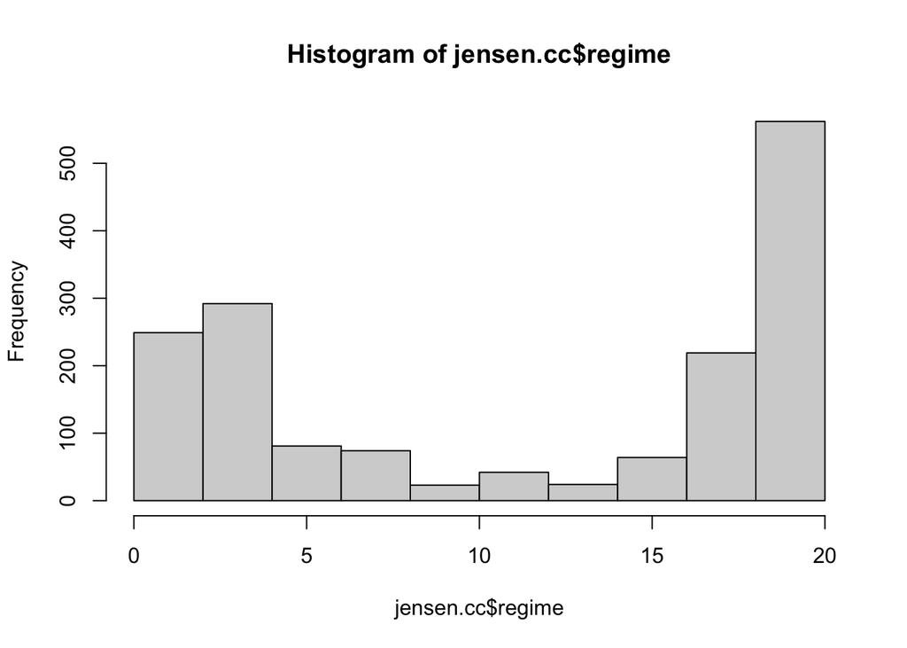

```r
hist(jensen.cc$regime)
```

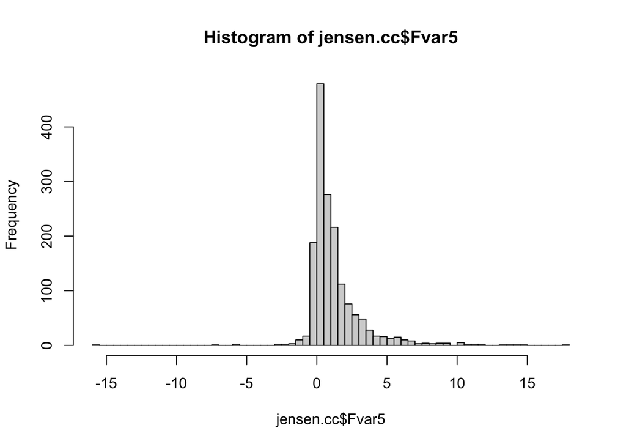

```r
hist(jensen.cc$Fvar5, 60)
```

```r
summary(jensen.cc$Fvar5)
```

```
    Min.  1st Qu.   Median     Mean  3rd Qu.     Max.
-15.5811   0.1485   0.6548   1.2422   1.6065  17.5164
```

For our purposes we won’t delve into the controls. The details of all of these can be found in the paper. We also won’t do the full elaborate analysis here, as the basic points about fixed effects and weighting can be made without it.

Time to fit three models. We’ll construct the formulas from a vector of variable names because we’re lazy. (Actually you’re not, but I am)

```r
X.vars <- c("var5", "market",   "lgdppc",   "gdpgrowt", "tradeofg",
                    "overallb", "generalg", "country", "d2", "d3") # these are the controls

# for predicting Fvar5 from the controls and regime
mod_f <- reformulate(c("regime", X.vars), response = "Fvar5")
mod_f
```

```
Fvar5 ~ regime + var5 + market + lgdppc + gdpgrowt + tradeofg +
    overallb + generalg + country + d2 + d3
```

```r
# for predicting regime from the controls
regime_mod_f <- reformulate(X.vars, response = "regime")
regime_mod_f
```

```
regime ~ var5 + market + lgdppc + gdpgrowt + tradeofg + overallb +
    generalg + country + d2 + d3
```

```r
# for predicting Fvar5 from the controls
fdi_mod_f <- reformulate(X.vars, response = "Fvar5")
fdi_mod_f
```

```
Fvar5 ~ var5 + market + lgdppc + gdpgrowt + tradeofg + overallb +
    generalg + country + d2 + d3
```

and fit the models

```r
mod <- lm(mod_f, data = jensen.cc)
mod_regime <- lm(regime_mod_f, data = jensen.cc)
mod_fdi <- lm(fdi_mod_f, data = jensen.cc)
```

```r
#summary(mod)
#summary(mod_regime)
#summary(mod_fdi)
```

What do the results of mod tell you about effect of regime on FDI? What can you tell about the size of the effect?

```r
coef(mod)
```

```
                    (Intercept)                          regime
                    7.780457471                     0.021076270
                           var5                          market
                    0.364187012                    -0.554160631
                         lgdppc                        gdpgrowt
                    0.834303144                     0.024384107
                       tradeofg                        overallb
                    0.005536112                    -0.023144342
                       generalg                  countryAlgeria
                   -0.039326633                    -0.769471182
               countryArgentina                countryAustralia
                   -0.217992323                    -0.156684320
                 countryAustria                  countryBahrain
                   -1.586641735                    -2.871117295
              countryBangladesh                  countryBelarus
                    0.529180752                    -1.314027486
                   countryBenin                  countryBolivia
                   -1.260463697                     0.488884957
                countryBotswana                   countryBrazil
                    0.009360162                     0.454031987
                countryBulgaria             countryBurkina Faso
                   -0.938846247                    -0.593858660
                 countryBurundi                 countryCameroon
                   -0.966488326                    -0.528641533
                  countryCanada countryCentral African Republic
                   -0.256858032                    -0.408461414
                    countryChad                    countryChile
                   -0.487813353                     0.202560398
                   countryChina                 countryColombia
                    4.383750701                    -0.011690212
                 countryComoros         countryCongo, Dem. Rep.
                   -1.628999726                    -0.101006264
             countryCongo, Rep.               countryCosta Rica
                   -1.230937361                    -0.878025808
           countryCote d'Ivoire                  countryCroatia
                   -0.378930160                    -0.459310911
          countryCzech Republic                  countryDenmark
                    0.090823832                    -1.366389756
                 countryEcuador         countryEgypt, Arab Rep.
                   -0.818150178                     1.142791926
```

[output cut: 69 more lines]

```
                   -0.650697012                     0.223848457
                    countryTogo      countryTrinidad and Tobago
                   -0.061607880                    -0.339656965
                 countryTunisia                   countryTurkey
                   -0.209753721                    -0.408240905
                  countryUganda           countryUnited Kingdom
                   -0.478112359                     0.543773036
           countryUnited States                  countryUruguay
                    0.591666113                    -1.515522627
               countryVenezuela              countryYemen, Rep.
                   -0.816505586                    -3.224999308
                  countryZambia                 countryZimbabwe
                    0.156703715                    -0.938322201
                             d2                              d3
                   -0.076561054                     0.263349623
```

a quick summary of `mod` suggests that a one unit increase in regime is associated with 0.02108 more of Fvar5.

```r
sd(jensen.cc$Fvar5)
```

```
[1] 1.980499
```

so this would be pretty substantively small as an effect.

FWL (Frische, Waugh and Lovell) suggest that we should be able to reconstruct that via the two other models. How would you go about this?

```r
res_regime <- resid(mod_regime)
res_fdi <- resid(mod_fdi)
lm(res_fdi ~ res_regime -1) # -1 means: leave out the intercept
```

```
Call:
lm(formula = res_fdi ~ res_regime - 1)

Coefficients:
res_regime
   0.02108
```

How do we relate this to heterogeneous treatment effects?

Lets go back to the weighting business. Let’s make those weights and add them to the data set.

```r
jensen.cc <- mutate(jensen.cc,
                    w = res_regime^2)
```

Now, who gets the highest weights? We’ll average the weights for observations from each country in all of its observations (in different years)

```r
jensen.country <- summarise(group_by(jensen.cc, country),
                            mean_w = mean(w))
```

And we can look at the *least* influential countries in our ATE:

```r
jc <- arrange(jensen.country, mean_w)
head(jc)
```

```
# A tibble: 6 x 2
  country                    mean_w
  <chr>                       <dbl>
1 Central African Republic 8.79e-31
2 Albania                  4.12e-27
3 Germany                  2.60e- 3
4 Russian Federation       4.21e- 3
5 Haiti                    4.36e- 3
6 Benin                    1.77e- 2
```

and *most* influential:

```r
tail(jc)
```

```
# A tibble: 6 x 2
  country     mean_w
  <chr>        <dbl>
1 Madagascar    38.9
2 Argentina     44.1
3 Philippines   44.1
4 Niger         45.6
5 Hungary       52.7
6 Uruguay       61.3
```

If you want to get an idea bout why these are influential it’s easy to plot them, as we did in the lecture

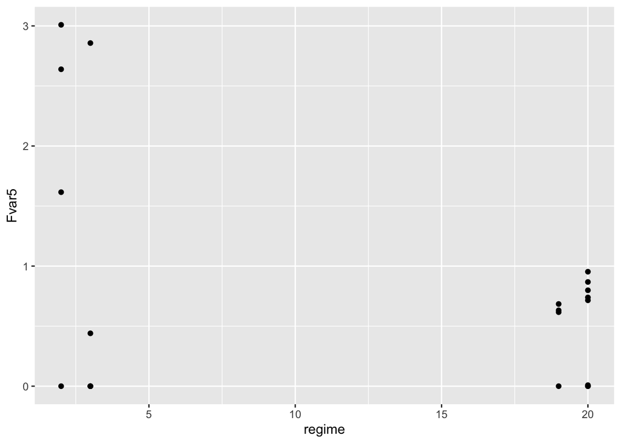

```r
ggplot(filter(jensen.cc, country == "Uruguay"),
       aes(regime, Fvar5)) +
  geom_point()
```

You can swap your own country names in there. Here’s Germany

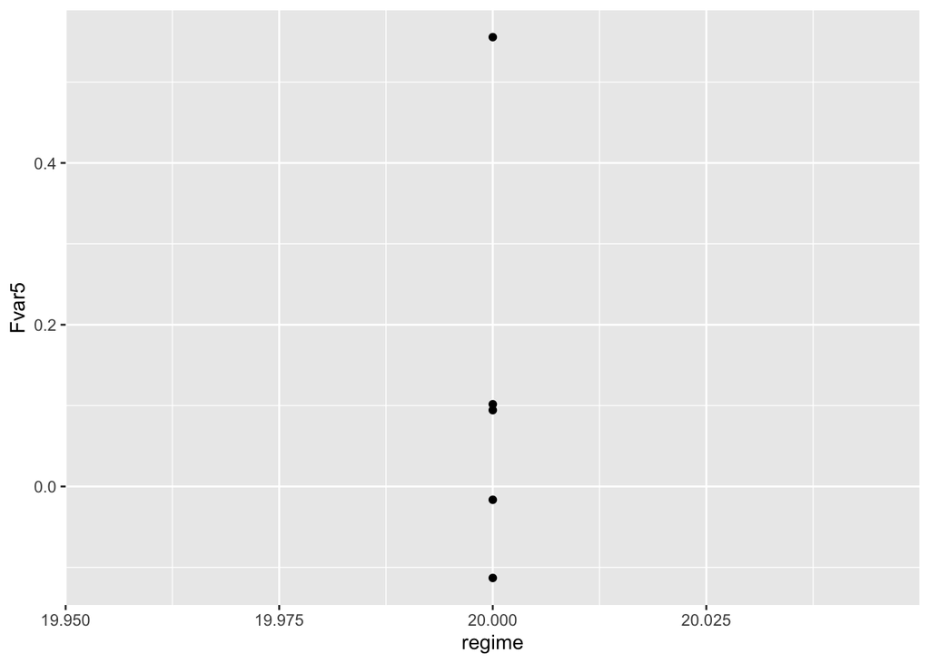

```r
ggplot(filter(jensen.cc, country == "Germany"),
       aes(regime, Fvar5)) +
  geom_point()
```

and, not quite so extreme, Madagascar

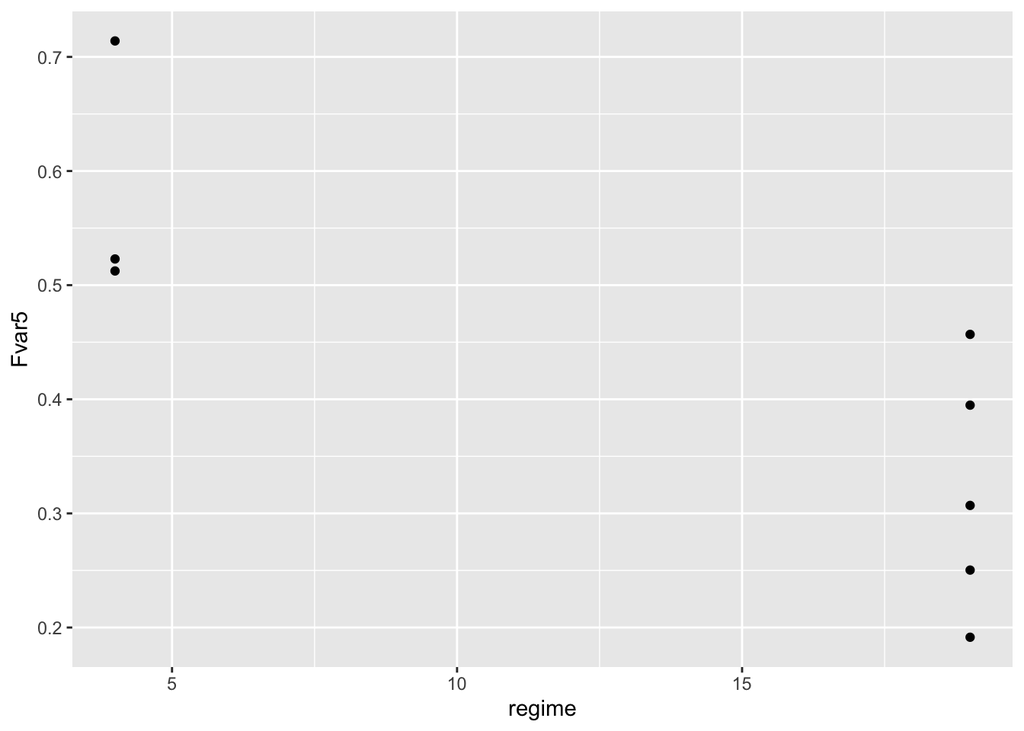

```r
ggplot(filter(jensen.cc, country == "Madagascar"),
       aes(regime, Fvar5)) +
  geom_point()
```

a sudden lurch in regime and variation in Fvar5 (in the opposite direction to the hypothesis, I note) means that this country’s data ‘matters more’ to the final coefficient value than somewhere like Germany does.

# Part 2

Question 2: Does controlling for “Z” in the following variables lead to bias reduction or amplification or an increase in precision?

X is the treatment and Y is the outcome

1. X <- Z -> M -> Y
2. X -> Y <- Z <- T
3. X -> R -> Y -> Z
4. X -> Z -> R -> Y